# (PART) 概率論 Probability

# 概率論入門：定義與公理

> **Statistics - A subject which most statisticians find difficult but which many physicians are experts on.**

> Stephen S. Senn

The Probability lectures were orgainised and taught by Professor [Elizabeth Williamson](https://www.lshtm.ac.uk/aboutus/people/williamson.elizabeth).

## 三個概率公理：

1. 對於任意事件 $A$，它發生的概率 $P(A)$ 滿足這樣的不等式： $0 \leqslant P(A) \leqslant 1$
2. $P(\Omega)=1$ , $\Omega$ 是全樣本空間 (total sample space)
3. 對於互斥（相互獨立）的事件 $A_1, A_2, \dots, A_n$ 有如下的等式關係： $P(A_1\cup A_2 \cup \cdots \cup A_n)=P(A_1)+P(A_2)+\cdots+P(A_n)$

你是不是覺得上面三條公理都是**廢話**。 不用擔心，我也是這麼覺得的。因爲所有人都認同的道理，才能成爲公理 (axiom)，因爲它們是不需要證明的自然而然形成的人人都接受的觀念。`(axiom: a saying that is widely accepted on its own merits; its truth is assumed to be self-evident)`

然而，正是這樣顯而易見的道理，確是拿來建築理論的基石，千萬不能小看了他們。例如，我們看下面這個看似也應該成爲公理的公式，你能證明嗎：

$$P(A_1\cup A_2) = P(A_1) + P(A_2) - P(A_1 \cap A_2)$$

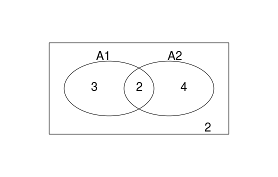

**證明：**

先考慮 $A_1 \cup A_2$ 是什麼（拆分成三個互斥事件）

$A_1 \cup A_2 = (A_1\cap \bar{A_2})\cup(\bar{A_1}\cap A_2)\cup(A_1\cap A_2)$

運用上面的公理2 3

$\therefore P(A_1 \cup A_2) = P(A_1\cap \bar{A_2}) + P(\bar{A_1}\cap A_2) + P(A_1\cap A_2) \;\;\;\;\;\;(1)$

再考慮 $A_1=(A_1\cap A_2)\cup(A_1\cap\bar{A_2})$ 繼續拆分成兩個互斥事件

$\therefore P(A_1)=P(A_1\cap A_2)+P(A_1\cap\bar{A_2})$ 整理一下：

$P(A_1\cap\bar{A_2})=P(A_1)-P(A_1\cap A_2)$

同理可得: $P(\bar{A_1}\cap A_2)=P(A_2)-P(A_1\cap A_2)$

代入上面第(1)式可得：

$$\begin{aligned}
P(A_1 \cup A_2) &= P(A_1)-P(A_1\cap A_2)\\
&\;\;+ P(A_2)-P(A_1\cap A_2)\\
&\;\;+P(A_1\cap A_2)\\
&=P(A_1) + P(A_2) - P(A_1 \cap A_2)
\end{aligned}$$

## 條件概率 Conditional probability

- $P(A|S)=\frac{P(A\cap S)}{P(S)}$
- $P(A\cap S) = P(A|S)P(S)$

## 獨立 (independence) 的定義

- 兩個事件定義爲互爲獨立時 ($A$ and $B$ are said to be independent **if and only if**)
  $$P(A\cap
  B)=P(A)P(B)$$
- 因爲從條件概率的概念我們已知  
  $P(A\cap B) = P(A|B)P(B)$  
  所以$P(A|B)=P(A)$ 即：事件 $B$ 無法提供事件 $A$ 的任何有效訊息 (**$A, B$ 互相獨立**)

## 賭博問題

終於來到本次話題的”重點”了。

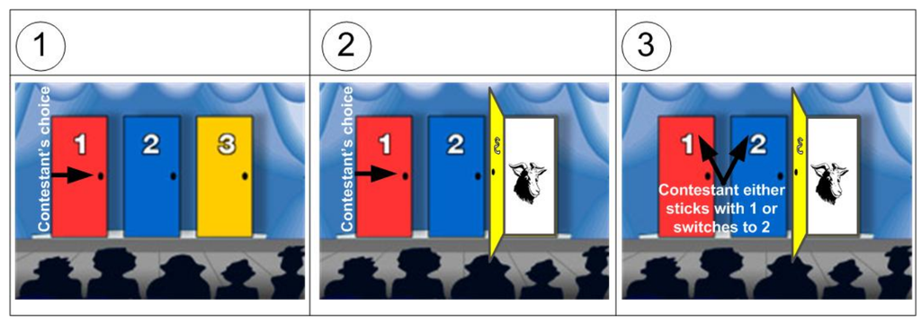

假設你在一個電視遊戲節目。有上圖一樣的三扇門。其中一扇門後面有一輛保時捷，另兩扇門後面則是[(味道奇特的)山羊](https://winterwang.github.io/post/black-meal/)。遊戲規則是主持人會讓你先選擇其中一扇門（先不打開你選的這扇門）。主持人隨後打開另外兩扇門中的一扇沒有保時捷的門。主持人問你，你要堅持選擇之前選中的那扇門，還是要改變主意換一扇門去猜是否可以猜中保時捷。 請問，堅持選擇之前選中的門猜中保時捷的概率高，還是主持人打開一扇門以後改變主意猜中保時捷的概率更高呢？

## 賭博問題的答案

**答案是：必須改變主意才能提高中獎概率。**

上述情況下，最簡單的是用概率樹 (probability tree) 來做決定：

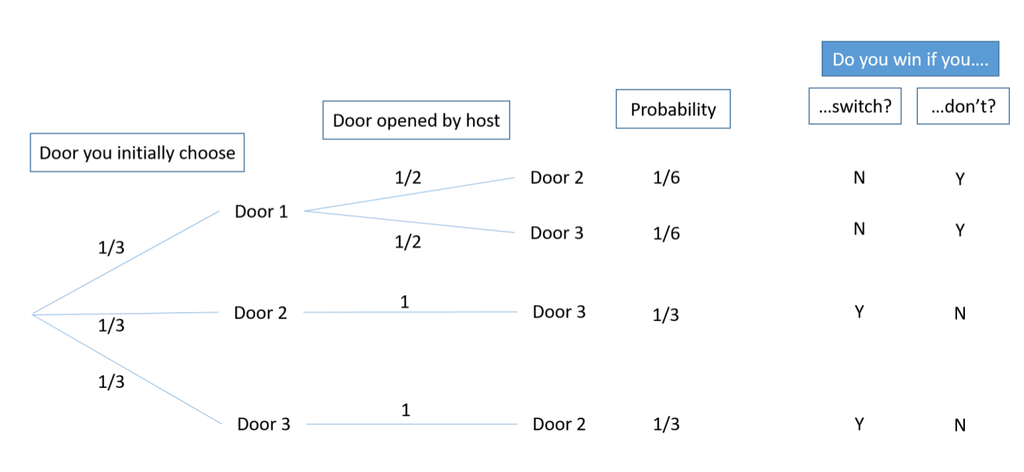

解說一下：

- 假定保時捷在1號門後，你第一次選擇了1號門，那麼此時主持人可以任意打開2號或者三號門（因爲他們後面都沒有保時捷）。
- 假定保時捷在1號門後，你第一次選了2號門，那麼此時主持人只能打開3號門（因爲一號門後是保時捷，按照遊戲規則主持人不能打開）。
- 假定保時捷在1號門後，你第一次選了3號門，那麼此時主持人只能打開2號門（因爲一號門後是保時捷，按照遊戲規則主持人不能打開）。

所以按照圖中給出的計算概率樹的過程可以得到:

$$P[\text{change}]=\frac{1}{3}+\frac{1}{3}=\frac{2}{3}\\
P[\text{not change}]=\frac{1}{6}+\frac{1}{6}=\frac{1}{3}$$

你是否選擇了改變主意了呢？

# Bayes 貝葉斯理論的概念

許多時候，我們需要將概率中的條件相互對調。 例如： 在已知該人羣中有20%的人有吸菸習慣($P(S)$)，吸菸的人有9%的概率有哮喘($P(A|S)$)，不吸菸的人有7%的概率有哮喘($P(A|\bar{S})$)的前提下，有個人前來門診，發現是哮喘患者，那麼這個人有多大的概率是一個菸民？也就是要求 $P(S|A)$

這裏先引入貝葉斯的概念：

我們可以將 $P(A\cap S)$ 寫成：
$$P(A\cap S)=P(A|S)P(S)\\or\\
P(A\cap S)=P(S|A)P(A)$$
這兩個等式是完全等價的。我們將他們連起來：

$$P(S|A)P(A)=P(A|S)P(S)\\
\Rightarrow P(S|A)=\frac{P(A|S)P(S)}{P(A)}$$

是不是看起來又像是寫了一堆**廢話**？ 沒錯，你看出來是一堆廢話的時候，證明你也同意這背後的簡單邏輯。

再繼續，我們可以利用另外一個**廢話**：

$$\because S+\bar{S}=1\\
\therefore P(A)=P(A\cap S)+P(A\cap\bar{S})$$

用上面的公式替換掉

$$P(A\cap S)+P(A\cap\bar{S}） \\
\therefore P(A)=P(A|S)P(S)+P(A|\bar{S})P(\bar{S})$$

可以得到**貝葉斯理論公式**：

$$P(S|A)=\frac{P(A|S)P(S)}{P(A|S)P(S)+P(A|\bar{S})P(\bar{S})}$$

回到上面說到的哮喘人中有多少比例吸菸的問題。可以繼續使用概率樹來方便的計算：

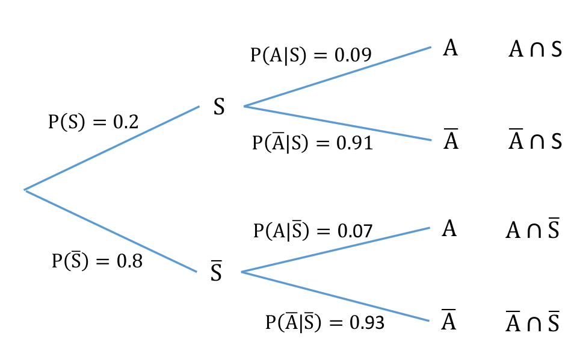

$$\begin{aligned}
P(S|A) &= \frac{P(A|S)P(S)}{P(A|S)P(S)+P(A|\bar{S})P(\bar{S})} \\
&= \frac{0.09\times0.2}{0.09\times0.2+0.07\times0.8} \\
&= 0.24
\end{aligned}$$

所以我們的結論就是，在已知該人羣中有20%的人有吸菸習慣($P(S)$)，吸菸的人有9%的概率有哮喘($P(A|S)$)，不吸菸的人有7%的概率有哮喘($P(A|\bar{S})$)的前提下，有個人前來門診，發現是哮喘患者，那麼這個人有24% 的概率是一個菸民($P(S|A)$)。

# 期望 Expectation (或均值 or mean) 和 方差 Variance

期望（或均值）是用來描述一組數據中心位置的指標（另一個是中位數 Median）。 對於離散型隨機變量 $X$ (discrete random variables)，它的期望被定義爲：

$$E(X)=\sum_x xP(X=x)$$

所以就是將所有 $X$ 可能取到的值乘以相應的概率後求和。這個期望（或均值）常常用希臘字母 $\mu$ 來標記。

方差 Variance 是衡量一組數據變化幅度(dispersion/variability)的指標之一。 方差的定義是：

$$Var(X)=E((X-\mu)^2)\\\text{Where,
}\mu=E(x)$$

實際上我們更加常用的是它的另外一個公式：

$$Var(X)=E(X^2)-E(X)^2$$

**證明 上面兩個方差公式相等**

$$\begin{align}
Var(x) &= E((X-\mu)^2) \\
&= E(X^2-2X\mu+\mu^2)\\
&= E(X^2) - 2\mu E(X) + \mu^2\\
&= E(X^2) - 2\mu^2 + \mu^2 \\
&= E(X^2) - \mu^2 \\
&= E(X^2) - E(X)^2
\end{align}$$

## 方差的性質：

1. $Var(X+b)=Var(X)$
2. $Var(aX)=a^2Var(X)$
3. $Var(aX+b)=a^2Var(X)$

# 伯努利分佈 Bernoulli distribution

伯努利分佈，說的就是一個簡單的二分變量 (1, 0)，它取1時的概率如果是 $\pi$。那麼我們可以計算這個分佈的期望值:

$$\begin{align}
E(X) &=\sum_x xP(X=x) \\
&=1\times\pi + 0\times(1-\pi)\\
&=\pi
\end{align}$$

由於 $x=x^2$，因爲 $x=0,1$, 所以 $E[X^2]=E[X]$，那麼方差爲：

$$\begin{align}
Var(X) &=E[X^2]-E[X]^2 \\
&=E[X]-E[X]^2 \\
&=\pi - \pi^2 \\
&=\pi(1-\pi)
\end{align}$$

證明，$X,Y$ 爲互爲獨立的隨機離散變量時，  
a) $E(XY)=E(X)E(Y)$ ;  
b) $Var(X+Y)=Var(X)+Var(Y)$

- 1. **證明**

$$\begin{align}
E(XY) &= \sum_x\sum_y xyP(X=x, Y=y) \\
\because &\; X,Y \text{are independent to each other} \\
\therefore &= \sum_x\sum_y xyP(X=x)P(Y=y)\\
&=\sum_x xP(X=x)\sum_y yP(Y=y)\\
&=E(X)E(Y)
\end{align}$$

- 2. **證明** 根據方差的定義：

$$\begin{align}
Var(X+Y) &= E((X+Y)^2)-E(X+Y)^2 \\
& \; \text{Expand} \\
&=E(X^2+2XY+Y^2)-(E(X)+E(Y))^2\\
&=E(X^2)+E(Y^2)+2E(XY)\\
&\;\;\; - E(X)^2-E(Y)^2-2E(X)E(Y)\\
&\; \text{We just showed}\; E(XY)=E(X)E(Y)\\
&=E(X^2)-E(X)^2+E(Y^2)-E(Y)^2 \\
&=Var(X)+Var(Y)
\end{align}$$

# 二項分佈的概念 Binomial distribution

二項分佈在醫學研究中至關重要，一組二項分佈的數據，指的通常是 $n$ 次相互獨立的[成功率爲 $\pi$ 的伯努利實驗](https://winterwang.github.io/post/probability2-4/) ($n$ independent Bernoulli trials) 中成功的次數。

當 $X$ 服從二項分佈，記爲 $X \sim binomial(n, \pi)$ 或$X \sim bin(n, \pi)$。它的(第 $x$ 次實驗的)概率被定義爲：

$$\begin{align}
P(X=x) &= ^nC_x\pi^x(1-\pi)^{n-x} \\
&= \binom{n}{x}\pi^x(1-\pi)^{n-x} \\
& for\;\; x = 0,1,2,\dots,n
\end{align}$$

## 二項分佈的期望和方差

- 期望 $E(X)$
  - 若 $X \sim bin(n,\pi)$，那麼 $X$ 就是這一系列獨立伯努利實驗中成功的次數。
  - 用 $X_i, i =1,\dots, n$ 標記每個相互獨立的伯努利實驗。
  - 那麼我們可以知道 $X=\sum_{i=1}^nX_i$。

$$\begin{align} E(X) &= E(\sum_{i=1}^nX_i)\\
&= E(X_1+X_2+\cdots+X_n) \\
&= E(X_1)+E(X_2)+\cdots+E(X_n)\\
&= \sum_{i=1}^nE(X_i)\\
&= \sum_{i=1}^n\pi \\
&= n\pi
\end{align}$$

- 方差 $Var(X)$

$$\begin{align}
Var(X) &= Var(\sum_{i=1}^nX_i) \\
&= Var(X_i+X_2+\cdots+X_n) \\
&= Var(X_i)+Var(X_2)+\cdots+Var(X_n) \\
&= \sum_{i=1}^nVar(X_i) \\
&= n\pi(1-\pi) \\
\end{align}$$

## 超幾何分佈 hypergeometric distribution

假設我們從總人數爲 $N$ 的人羣中，採集一個樣本 $n$。假如已知在總體人羣中($N$)有 $M$ 人患有某種疾病。請問採集的樣本 $X=n$ 中患有這種疾病的人，服從怎樣的分佈？

- 從人羣($N$)中取出樣本($n$)，有 $^NC_n$ 種方法。
- 從患病人羣($M$)中取出患有該病的人($x$)有 $^MC_x$ 種方法。
- 樣本中不患病的人($n-x$)被採樣的方法有 $^{N-M}C_{n-x}$ 種。
- 採集一次 $n$ 人作爲樣本的概率都一樣。因此：

$$P(X=x)=\frac{\binom{M}{x}\binom{N-M}{n-x}}{\binom{N}{n}}$$

## 樂透中獎概率問題：

- 從數字 $1\sim59$ 中選取 $6$ 個任意號碼
- 開獎時從 $59$ 個號碼球中隨機抽取 $6$ 個
- 如果六個號碼全部猜中(不分順序)，你可以成爲百萬富翁。請問一次猜中全部 $6$ 個號碼的概率是多少？

從 $59$ 個號碼中隨機取出任意 $6$ 個號碼的方法有 $^{59}C_6$ 種。
$$^{59}C_6=\frac{59!}{6!(59-6)!}=45,057,474$$

每次選取六個號碼做爲一組的可能性相同，所以，你買了一組樂透號碼，能中獎的概率就是 $1/45,057,474 = 0.00000002219$。你還會再去買彩票麼？

### 如果我只想中其中的 $3$ 個號碼，概率有多大？

用超幾何分佈的概率公式：

$$\begin{align}
P(X=3) &= \frac{^6C_3\times ^{53}C_3}{^{59}C_6} \\
&= 0.010
\end{align}$$

# 泊松分佈 Poisson Distribution

- 當一個事件，在一段時間 ($T$) 中可能發生的次數是 $\lambda$ 。那麼我們可以認爲，經過時間 $T$，該事件發生的期望次數是 $E(X)=\lambda T$。
- 利用微分思想，將這段時間 $T$ 等分成 $n$ 個時間段，當 $n\rightarrow\infty$ 直到每個微小的時間段內最多發生一次該事件。

那麼

- 每個微小的時間段，可以視爲是一個伯努利實驗（有事件發生或者沒有）
- 那麼這整段時間 $T$ 內發生的事件可以視爲是一個二項分佈實驗。

令 $X=$ 一次事件發生時所經過的所有時間段。

- $X \sim Bin(n, \pi)$，其中 $n\rightarrow\infty$，$n$ 爲時間段。
- 在每個分割好的時間段內，事件發生的概率都是：$\pi=\frac{\lambda T}{n}$
- 期望 $\mu=\lambda T \Rightarrow \pi=\mu/n$
- 所以 $X$ 的概率方程就是：

$$\begin{align}
P(X=x) &= \binom{n}{x}\pi^x(1-\pi)^{n-x} \\
&= \binom{n}{x}(\frac{\mu}{n})^x(1-\frac{\mu}{n})^{n-x} \\
&=
\frac{n!}{x!(n-x)!}(\frac{\mu}{n})^x(1-\frac{\mu}{n})^{n-x} \\
&=\frac{n!}{n^x(n-x)!}\frac{\mu^x}{x!}(1-\frac{\mu}{n})^{n-x}\\
\text{when}\; n\rightarrow\infty &\; x \ll n\\
\frac{n!}{n^x(n-x)!} &=\frac{n(n-1)\dots(n-x+1)}{n^x} \rightarrow
1\\
(1-\frac{\mu}{n})^{n-x} &\approx (1-\frac{\mu}{n})^n \rightarrow
e^{-\mu}\\
\text{the probability function } & \text{ of a Poisson
distribution} \\
P(X=x) &\rightarrow \frac{\mu^x}{x!}e^{-\mu}
\end{align}$$

當數據服從泊松分佈時，記爲 $X\sim Poisson(\mu=\lambda T)\;\; or\;\; X\sim Poi(\mu)$

**證明泊松分佈的參數特徵：**

1. $E(X)=\mu$

$$\begin{align}
E(X) &= \sum_{x=0}^\infty xP(X=x) \\
&= \sum_{x=0}^\infty x\frac{\mu^x}{x!}e^{-\mu} \\
&= 0+ \sum_{x=1}^\infty x\frac{\mu^x}{x!}e^{-\mu} \\
&= \sum_{x=1}^\infty \frac{\mu^x}{(x-1)!}e^{-\mu} \\
&= \mu\sum_{x=1}^\infty \frac{\mu^{x-1}}{(x-1)!}e^{-\mu} \\
\text{replace}\; &x\; \text{with all}\; i=x-1 \\
&= \mu\sum_{i=0}^\infty \frac{\mu^{i}}{i!}e^{-\mu} \\
\text{notice that}\; & \text{the right side} \sum_{i=0}^\infty
\frac{\mu^{i}}{i!}e^{-\mu}=1 is \\
\text{the sum of all}\;& \text{probability of a Poisson
distribution}\\
&= \mu
\end{align}$$

2. $Var(x)=\mu$ 爲了找到 $Var(X)$，我們用公式 $Var(X)=E(X^2)-E(X)^2$

我們需要找到 $E(X^2)$

$$\begin{align}
E(X^2) &= \sum_{x=0}^\infty x^2\frac{\mu^x}{x!}e^{-\mu} \\
&= \mu \sum_{x=1}^\infty x\frac{\mu^{x-1}}{(x-1)!}e^{-\mu} \\
\text{replace}\; &x\; \text{with all}\; i=x-1 \\
&= \mu \sum_{i=0}^\infty (i+1)\frac{\mu^{i}}{i!}e^{-\mu} \\
&= \mu(\sum_{i=0}^\infty i\frac{\mu^i}{i!}e^{-\mu} +
\sum_{i=0}^\infty \frac{\mu^i}{i!}e^{-\mu}) \\
&= \mu(E(X)+1) \\
&= \mu^2+\mu \\
Var(X) &= E(X^2) - E(X)^2 \\
&= \mu^2 + \mu -\mu^2 \\
&= \mu
\end{align}$$

# 正（常）態分佈 Normal Distribution

## 概率密度曲線 probability density function， PDF

- 一個隨機連續型變量 $X$ 它的性質由一個對應的**概率密度方程 (probability density function, PDF)** 決定。
- 在給定的範圍區間內，如 $a\sim b, (a < b)$，它的概率滿足:

$$P(a\leqslant X \leqslant b) =
\int_a^bf(x)dx$$

- 這個相關的方程，在 $a\sim b$ 區間內的積分，就是這個連續變量在這個區間內取值的概率。

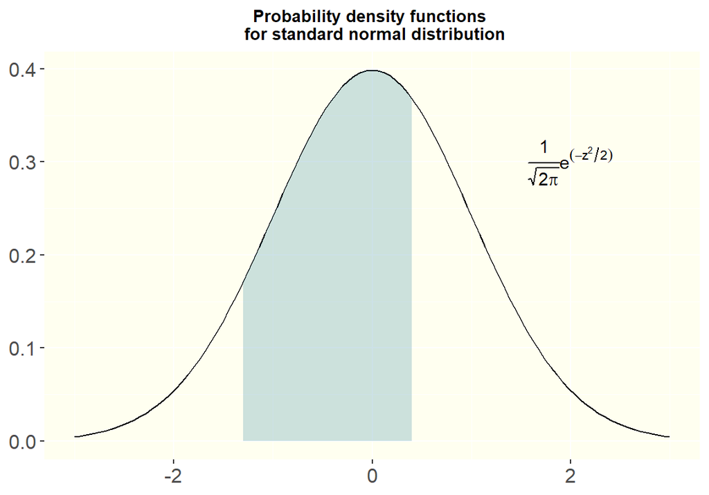

Probability Density Function of a Standard Normal Distribution

```r
# R codes for drawing a standard normal distribution by using ggplot2
p <- ggplot(data.frame(x=c(-3,3)), aes(x=x)) +
  stat_function(fun = dnorm)
p + annotate("text", x=2, y=0.3, parse=TRUE, label="frac(1, sqrt(2*pi)) * e ^(-z^2/2)") +
  theme(plot.subtitle = element_text(vjust = 1),
        plot.caption = element_text(vjust = 1),
        axis.text.x = element_text(size = 12),
        axis.text.y = element_text(size = 12),
        plot.title = element_text(size = 10, face = "bold", hjust = 0.5),
        panel.background = element_rect(fill = "ivory")) +
  labs(title = "Probability density functions \n for standard normal distribution",
       x = NULL, y = NULL) +
  stat_function(fun = dnorm,
                xlim = c(-1.3,0.4),
                geom = "area",fill="#00688B", alpha= 0.2)
```

注意：整個方程的曲線下面積等於 $1$：
$$\int_{-\infty}^\infty f(x)dx=1$$

- 期望 $E(X)=\int_{-\infty}^\infty xf(x)dx$
- 方差 $Var(X)=\int_{-\infty}^\infty (x-\mu)^2f(x)dx$

## 正（常）態分佈

如果一組數據服從正（常）態分佈，我們通常用它的期望（或者叫平均值）$\mu$，和它的方差 $\sigma^2$，來描述這組數據。記爲：

$$X \sim N(\mu, \sigma^2)$$

- 它的概率密度方程可以表述爲：

$$f(x)=\frac{1}{\sqrt{2\pi\sigma^2}}exp(-\frac{(x-\mu)^2}{2\sigma^2})$$

- $E(x) =\mu$
- $Var(x)=\sigma^2$

## 標準正（常）態分佈

標準正（常）態分佈的期望（或者均值）爲 $0$，方差爲 $1$

- 記爲：$Z \sim N(0,1)$
- 它的概率密度方程表述爲：

$$\frac{1}{\sqrt{2\pi}}exp(-\frac{z^2}{2})$$

- 它的累積分佈方程 (cumulative distribution function， CDF)，是將概率密度方程 (PDF) 積分以後獲得的方程。通常我們記爲 $\Phi(z)$

再看一下標準正（常）態分佈的概率密度方程曲線：

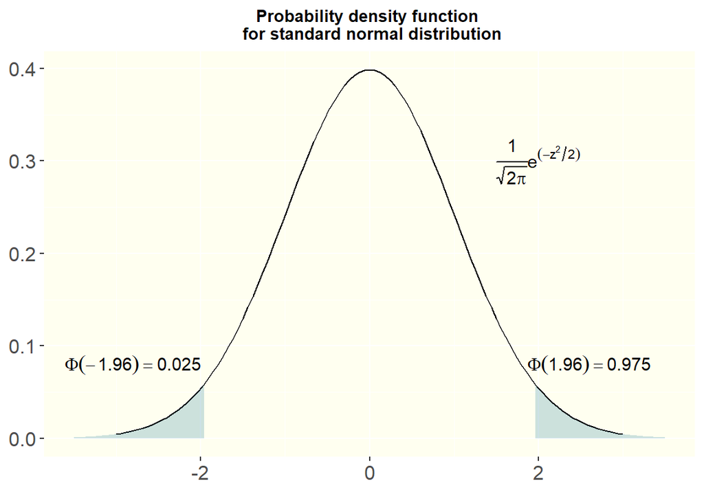

Probability Density function of a Standard Normal Distribution

- 95% 的曲線下面積在標準差 standard deviation $-1.96\sim1.96$ 之間的區域。
- 而且，$\phi(-x)=1-\phi(x)$
- 任何一個正（常）態分佈都可以通過下面的公式，標準化成爲標準正（常）態分佈：

$$Z=\frac{X-\mu}{\sigma}$$

# 中心極限定理 the Central Limit Theorem

最近明顯可以感覺到課程的步驟開始加速。看我的課表：

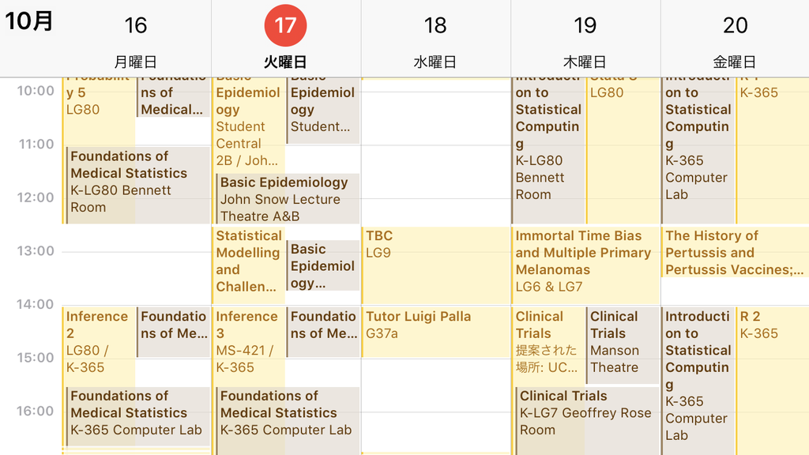

手機畫面太小了。早上都是9點半開始，下午基本都是到5點。週一更慘，到7點。週二-週五中午都被統計中心的講座佔據。簡直是非人的生活。

這周概率論基礎結束。中心極限定理講完以後我們正式進入了 Inference 統計推斷的課程。我們花了一天時間講什麼是樣本估計 (Estimation)，什麼是參數精確度 (Precision)，什麼是自由度 (degree of freedom)，怎樣進行不偏的估計 (unbiased inference)。然後還有似然方程 (likelihood function)。

今天的更新還是簡單的把概率論掃尾一下。感受一下中心極限定理的偉大。

## 協方差 Covariance

[之前我們定義過](https://winterwang.github.io/post/probability2-4/)，兩個獨立連續隨機變量 $X,Y$ 之和的方差 Variance ：

$$\text{Var}(X+Y)=\text{Var}(X)+\text{Var}(Y)$$

然而如果他們並不相互獨立的話：

$$\begin{aligned}
\text{Var}(X+Y) &= E[((X+Y)-E(X+Y))^2] \\
&= E[(X+Y)-(E(X)+E(Y))^2] \\
&= E[(X-E(X)) - (Y-E(Y))^2] \\
&= E[(X-E(X))^2+(Y-E(Y))^2 \\
& \;\;\; +2(X-E(X))(Y-E(Y))] \\
&= \text{Var}(X)+\text{Var}(Y)+2E[(X-E(X))(Y-E(Y))]
\end{aligned}$$

可以發現在兩者和的方差公式展開之後多了一部分 $E[(X-E(X))(Y-E(Y))]$。 這個多出來的一部分就說明了二者 $(X, Y)$ 之間的關係。它被定義爲協方差 (Covariance):
$$\text{Cov}(X,Y) =
E[(X-E(X))(Y-E(Y))]$$

所以：

$$\text{Var}(X+Y)=\text{Var}(X)+\text{Var}(Y)+2Cov(X,Y)$$

要記住，協方差只能用於評價$X,Y$之間的線性關係 (Linear Association)。

以下是協方差 (Covariance) 的一些特殊性質：

1. $\text{Cov}(X,X)=\text{Var}(X)$
2. $\text{Cov}(X,Y)=\text{Cov}(Y,X)$
3. $\text{Cov}(aX,bY)=ab\:\text{Cov}(X,Y)$
4. $$\text{Cov}(aR+bS,cX+dY)=ac\:\text{Cov}(R,X)+ad\:\text{Cov}(R,Y)\\
   \;\;\;\;\;\;\;\;\;\;\;\;\;\;\;\;\;\;\;\;\;\;\;\;\;\;\;\;\;\;\;\;\;\;\;\;\;+bc\:\text{Cov}(S,X)+bd\:\text{Cov}(S,Y)$$
5. $$\text{Cov}(aX+bY,cX+dY)=ac\:\text{Var}(X)+ad\:\text{Var}(Y)\\
   \;\;\;\;\;\;\;\;\;\;\;\;\;\;\;\;\;\;\;\;\;\;\;\;\;\;\;\;\;\;\;\;\;\;\;\;\;+(ad+bc)\text{Cov}(X,Y)$$
6. $\text{Cov}(X+Y,X-Y)=\text{Var}(X)-\text{Var}(Y)$
7. If $X, Y$ are independent. $\text{Cov}(X,Y)=0$ But not vise-versa !

## 相關 Correlation

- 協方差雖然$\text{Cov}(X,Y)$ 的大小很大程度上會被他們各自的單位和波動大小左右。
- 我們將協方差標準化(除以各自的標準差 s.d.) (standardization) 之後，就可以得到相關係數 Corr ($-1\sim1$):
  $$\text{Corr}(X,Y)=\frac{\text{Cov}(X,Y)}{\text{SD}(X)\text{SD}(Y)}=\frac{\text{Cov}(X,Y)}{\sqrt{\text{Var}(X)\text{Var}(Y)}}$$

## 中心極限定理 the Central Limit Theorem

**如果從人羣中多次選出樣本量爲 $n$ 的樣本，並計算樣本均值, $\bar{X}_n$。那麼這個樣本均值 $\bar{X}_n$ 的分佈，會隨着樣本量增加 $n\rightarrow\infty$，而接近正（常）態分佈。**

偉大的中心極限定理告訴我們：

**當樣本量足夠大時，樣本均值 $\bar{X}_n$ 的分佈爲正（常）態分佈，這個特性與樣本來自的人羣的分佈 $X_i$ 無關。**

**再說一遍：**

如果對象是獨立同分佈 i.i.d (identically and independently distributed)。那麼它的總體期望和方差分別是: $E(X)=\mu;\;Var(X)=\sigma^2$。 根據中心極限定理，可以得到：

- 當樣本量增加，樣本均值的分佈服從正（常）態分佈：
  $$\bar{X}_n\sim N(\mu,
  \frac{\sigma^2}{n})$$
- 也可以寫作，當樣本量增加：
  $$\sum_{i=1}^nX_i \sim
  N(n\mu,n\sigma^2)$$
- 有了這個定理，我們可以拋開樣本空間($X$)的分佈，也不用假定它服從正（常）態分佈。
- 但是樣本的均值，卻總是服從正（常）態分佈的。簡直是太完美了！！！！！！

## 二項分佈的正（常）態分佈近似

- 假設我們有大量($n\rightarrow\infty$)的二項分佈實驗 $X\sim Bin(n, \pi)$
- 根據[二項分佈的概率公式](https://winterwang.github.io/post/probability3/)，計算將會變得很繁瑣複雜。
- 解決辦法：應用中心極限定理。
- [中心極限定理](https://winterwang.github.io/post/probability3/)告訴我們，當樣本量足夠大時:
  $$X\sim N(n\pi,
  n\pi(1-\pi))$$
- 問題在於，多大的 $n$ 才能算大樣本呢？
  - 當且僅當 (only and if only) $n>20$ AND $n\pi>5$ AND $n(1-\pi)>5$

## 泊松分佈的正（常）態分佈近似

- 假設時間 $t$ 內某事件的發生次數服從泊松分佈 $X\sim Po(\mu)$。
- 考慮將這段時間 $t$ 等分成 $n$ 個時間段。那麼第 $i$ 時間段內事件發生次數依舊服從泊松分佈 $X_i\sim Po(\frac{\mu}{n})$。且 $E(X_i)=\mu/n, Var(X_i)=\mu/n$。
- 那麼原先的 $X$ 可以被視爲是將這無數的小時間段的 $X_i$ 相加。應用中心極限定理：
  $$X=\sum_{i=1}^nX_i\sim N(\frac{n\mu}{n},
  \frac{n\mu}{n})$$
- 需要注意的是，這段時間 ($t$) 內發生的事件次數 ($\lambda$) : $\lambda t =\mu>10$ ，這樣的正（常）態分佈模擬才能成立。

## 正（常）態分佈模擬的校正：continuity corrections

- 如果我們使用正（常）態分佈來模擬離散變量的分佈，常常需要用到正（常）態分佈模擬的矯正。
- 例如：我們如果用正（常）態分佈模擬來計算 $P(X=15)$，那麼實際上我們應該計算的是 $P(14.5<X<15.5)$。

### 例題

1. 已知 $X\sim Bin(100,0.5)$，求 $P(X>60)$

**解**

$$\begin{aligned}
\because X&\sim Bin(100, 0.5) \\ \therefore E(X) &=n\pi=50 \\
Var(X) &= n\pi(1-\pi) =25=5^2\\
P(X>60) &= 1-P(X\leqslant60) \\
&= 1-P(Z\leqslant\frac{60.5-50}{\sqrt{25}}) \\
&= 1-P(Z\leqslant2.1) \\
&= 1-\Phi(2.1) \\
&= 1-0.982 = 0.018
\end{aligned}$$

```r
# 快來看實際用傻瓜算法計算獲得的概率：
1-pbinom(60, size=100, prob=0.5)
```

```
## [1] 0.0176
```

```r
# 快來看用中心極限定理模擬正（常）態分佈獲得的概率：
1-pnorm((60.5-50)/sqrt(25))
```

```
## [1] 0.01786
```

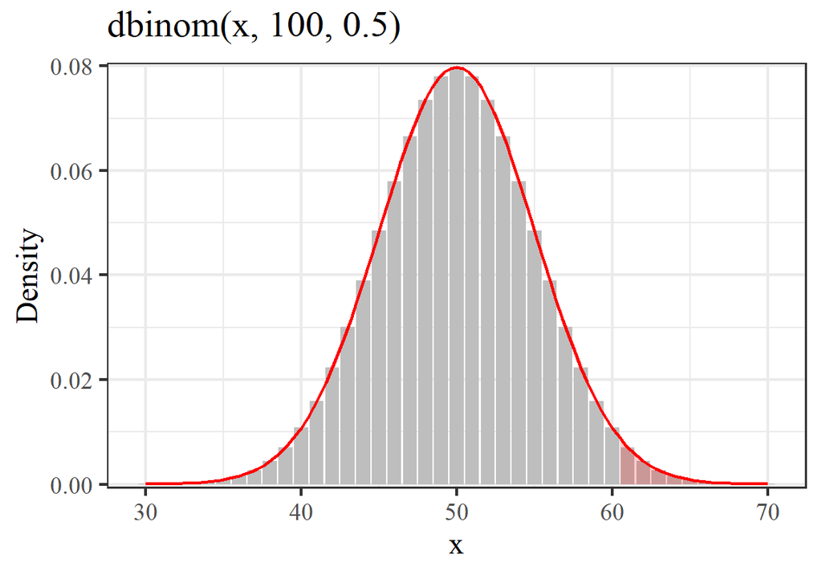

2. 已知 $X\sim Bin(48, 0.75)$, 求 $P(30<X<39)$

**解**

$$\begin{aligned}
\because B &\; \sim Bin(48, 0.75) \\
\therefore E(X) &\; =n\pi=36 \\
\text{Var}(X) &\; =n\pi(1-\pi)=9=3^2 \\
P(30<X<39) &\; = P(31\leqslant X\leqslant 38)\\
&\; = P(30.5\leqslant Y \leqslant 38.5) \\
Y\text{ is the }& \text{ normal approximation} \\
&\;= P(Y<38.5) - P(Y<30.5) \\
&\;= P(Z\leqslant\frac{38.5-36}{3})-
P(Z\leqslant\frac{30.5-36}{3}) \\
&\;= P(Z\leqslant0.833) - P(Z\leqslant-1.833) \\
&\;= \Phi(0.833)-\Phi(-1.833) \\
&\;= 0.798-0.033 = 0.764
\end{aligned}$$

```r
# 快來看實際用傻瓜算法計算獲得的概率：
pbinom(38, size=48, prob=0.75)-pbinom(30, size=48, prob=0.75)
```

```
## [1] 0.7578
```

```r
# 快來看用中心極限定理模擬正（常）態分佈獲得的概率：
pnorm((38.5-36)/sqrt(9)) - pnorm((30.5-36)/sqrt(9))
```

```
## [1] 0.7643
```

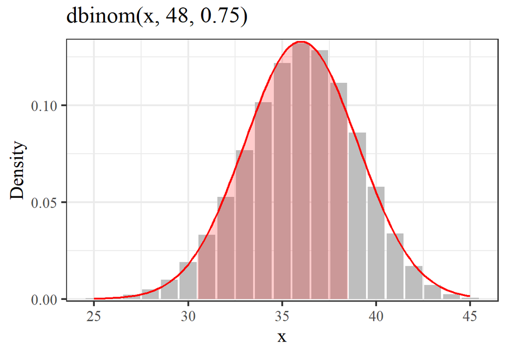

Probability of 30-39 successes out of 48 Binomial trials, probability of success = 0.75

從上面兩個例題也能看出，$n$ 越小，正（常）態分佈模擬的誤差就越大。

3. 已知 $X \sim Poisson(30)$ 求 $P(X\leqslant20)$。

**解**

$$\because E(X)=\mu=30, \;Var(X)=\mu=30=(\sqrt{30})^2 \\
\begin{aligned}
Pr(X\leqslant20) &= P(Z\leqslant\frac{20.5-30}{\sqrt{30}}) \\
&= P(Z\leqslant-1.734) \\
&= \Phi(-1.734) \\
&= 0.0414
\end{aligned}$$

```r
# 快來看實際用傻瓜算法計算獲得的概率：
ppois(20, lambda=30)
```

```
## [1] 0.03528
```

```r
# 快來看用中心極限定理模擬正（常）態分佈獲得的概率：
pnorm((20.5-30)/sqrt(30))
```

```
## [1] 0.04142
```

這兩個其實有些小差距。不過看下圖，其模擬還是很到位的。只是正（常）態分佈的面積明顯確實比泊松分佈的小柱子面積要大一些。

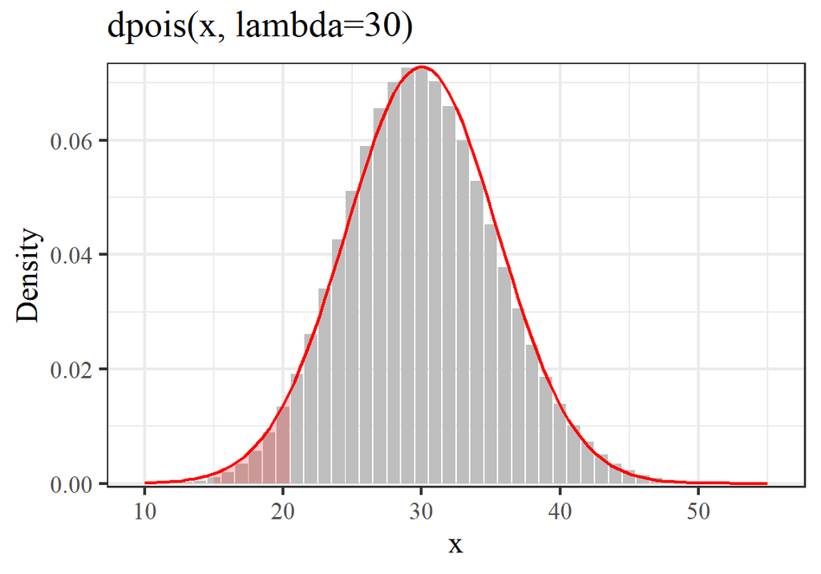

Probability of less than 20 events happen when the expectation is 30

4. 已知 $X_1, X_2 \stackrel{i.i.d}{\sim} Poi(30)$ 求 $P(X_1+X_2\leqslant40)$。

**解**

$$\begin{aligned}
E(X_1+X_2) &\;= E(X_1)+E(X_2) = 30+30 = 60\\
Var(X_1+X_2) &\;= Var(X_1)+Var(X_2) = 30+30 \\
&\;= (\sqrt{60})^2 \\
P(X_1+X_2\leqslant 40) &\;= P(Z \leqslant \frac{40.5-60}{\sqrt{60}})
\\
&\;= P(Z\leqslant-2.517) \\
&\;= \Phi(-2.517) \\
&\;= 0.006
\end{aligned}$$

```r
# 快來看實際用傻瓜算法計算獲得的概率：
ppois(40, lambda=60)
```

```
## [1] 0.003983
```

```r
# 快來看用中心極限定理模擬正（常）態分佈獲得的概率：
pnorm((40.5-60)/sqrt(60))
```

```
## [1] 0.005911
```

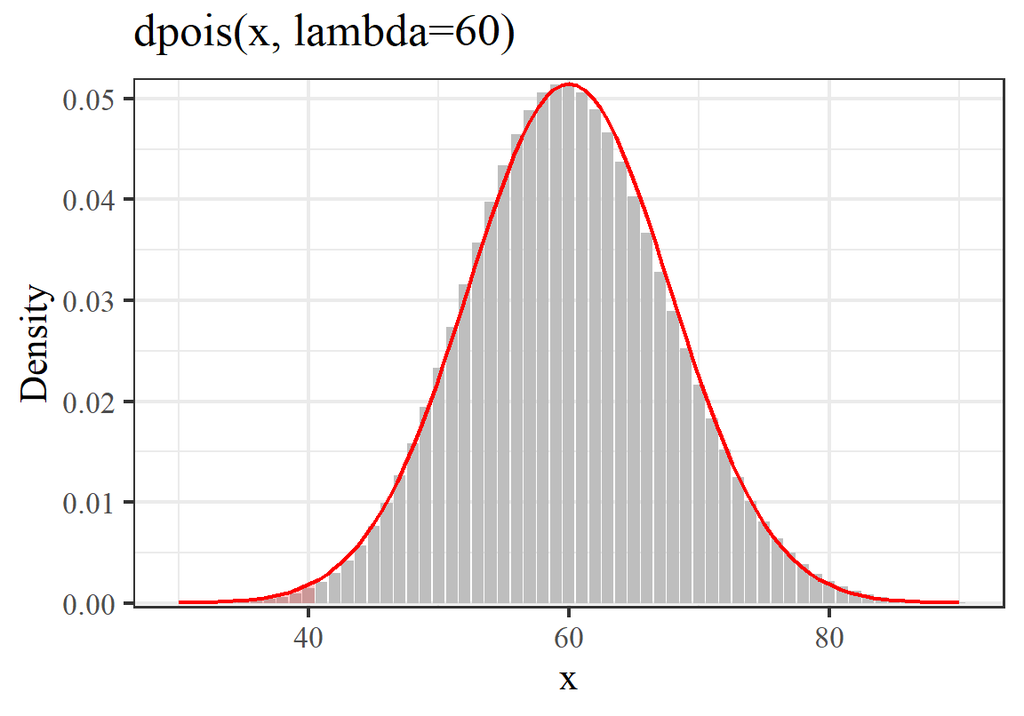

Probability of 2 identically and independently observed results of less or equal to 40 events happen in total when the expectation of each observation is 30

又一次，正（常）態分佈的面積比泊松分佈的小柱子面積要大一些。

## 兩個連續隨機變量

- 假定 $X_1, X_2$ 是兩個連續隨機變量：
  $$E(X_1)=\mu_1, \text{Var}(X_1)=\sigma_1^2 \\
  E(X_2)=\mu_2, Var(X_2)=\sigma_2^2 \\
  Corr(X_1, X_2)=\rho \Rightarrow \text{Cov}(X_1,
  X_2)=\rho\sigma_1\sigma_2=\sigma_{12}$$
- 利用矩陣的標記法，可以將 $X_1, X_2$ 標記爲 $\textbf{X}=(X_1, X_2)^T$, 即：

$$\textbf{X}=\left(
\begin{array}{c}
X_1\\
X_2\\
\end{array}
\right)$$

- 上面的所有內容都可以標記爲：
  $$E(\textbf{X})=\mathbf{\mu}=\left(
  \begin{array}{c}
  \mu_1\\
  \mu_2\\
  \end{array}
  \right)\\
  Covariance \;matrix: \\
  Var(\textbf{X})=\mathbf{\Sigma}=\left(
  \begin{array}{c}
  \sigma_1^2 & \sigma_{12}\\
  \sigma_{12} & \sigma_2^2\\
  \end{array}
  \right)$$

## 兩個連續隨機變量 例子：

假如要看收縮期血壓 ($SBP$) 和舒張期血壓 ($DBP$) 之間的關係：

下列爲已知條件：

- $SBP$ 的均值爲 $130$, 標準差爲 $15$;
- $DBP$ 的均值爲 $90$, 標準差爲 $10$;
- $SBP$ 和 $DBP$ 之間的相關係數爲 $0.75$。

那麼， 我們可以把這些信息用下面的方法來標記：

$$E(\textbf{X})=\mathbf{\mu}=\left(
\begin{array}{c}
130\\
90\\
\end{array}
\right)\\
Var(\textbf{X})=\mathbf{\Sigma}=\left(
\begin{array}{c}
15^2 = 225 & 0.75 \times 15 \times 10 = 112.5\\
0.75 \times 15 \times 10 = 112.5 & 10^2 = 100\\
\end{array}
\right)$$

## 條件分佈和邊緣分佈的概念

- 如果 $\textbf{X}=(X_1, X_2)^T$ 的兩個變量都服從正（常）態分佈；
- 那麼這兩個變量的邊緣分佈 (marginal distribution) 也服從正（常）態分佈:
  $$X_1\sim
  N(\mu_1,\sigma_1^2), X_2\sim N(\mu, \sigma_2^2)$$
- 同樣的，$X_1$ 的給出 $X_2$ 的條件分佈 (condition distribution) 也服從正（常）態分佈：
  $$E(X_1|X_2)=\mu_1+\frac{\rho\sigma_1}{\sigma_2}(X_2-\mu_2)
  \\
  \text{Var}(X_1|X_2)=\sigma_1^2(1-\rho^2)$$
- 反之亦然。

## 條件分佈和邊緣分佈的例子

上面的概念過於抽象，用血壓的例子：

收縮期血壓和舒張期血壓各自服從正（常）態分佈。那麼可以用上面的概念來寫出已知舒張期血壓時，收縮期血壓的分佈。

- 條件期望:
  $$E(\text{SBP|DBP})=130+\frac{0.75\times15}{10}(\text{DBP}-90)$$
- 實際如果來了一個病人，他說他只記得自己測的舒張期血壓是95：
  他的收縮期血壓的期望值就可以用上面的式子計算：
  $$E(\text{SBP|DBP}=95)=136$$
- 條件方差爲：
  $$\text{Var}(\text{SBP|DBP})=15^2(1-0.75^2)=98.4\approx9.92^2<15^2$$
- 所以當我們知道了這個人的一部分信息以後，推測他的另一個相關連的變量變得更加準確(**方差變小**)了。

### 例題

有 (閒) 人記錄了 $1494$ 名兒童在 $2, 4, 6$ 歲時的腿長度。已知在記錄的這三個年齡時的平均腿長度分別爲 $85 \text{ cm}, 103 { cm}, 114 { cm}$。協方差矩陣如下:

$$\left(
\begin{array}{c}
22.2 & 11.8 & 13.7\\
11.8 & 26.3 & 21.5\\
13.7 & 21.5 & 29.0
\end{array}
\right)$$

假定，這三個年齡記錄的這些兒童的腿長度數據（聯合分佈, joint distribution）服從三個變量正（常）態分佈。

1. 求 $2$ 歲時這些兒童的腿長度的邊緣分佈 (marginal distribution)

**解**

$$X_{\text{age}=2} \sim N(85,
\sigma_{\text{age}=2}^2=22.2)$$

2. 求他們 $6$ 歲時腿長度的 $2$ 歲時的條件分佈。(Find the distribution of leg length age 6 conditional on leg length at age 2.)

**解**

$6$ 歲時和 $2$ 歲時腿長的相關係數 (correlation, $\rho_{6,2}$) 爲：

$$\begin{aligned}
\rho_{6,2} &=
\frac{Cov_{6,2}}{\sqrt{\text{Var}(\text{length}_6)}\sqrt{\text{Var}(\text{length}_2)}}\\
&= \frac{13.7}{\sqrt{22.2}\sqrt{29}}=0.54
\end{aligned}$$

條件分佈套用上面提到的公式：

$$\begin{aligned}
E({\text{length}_6 | \text{length}_2}) &=
\mu_6+\frac{\rho_{6,2}\sigma_6}{\sigma_2}(\text{length}_2-\mu_2) \\
&=
114+\frac{0.54\times\sqrt{29.0}}{\sqrt{22.2}}(\text{length}_2-85)\\
\text{Var}(\text{length}_6 | \text{length}_2) &=
\sigma_6^2(1-\rho_{6,2}^2) \\
&= 29.0\times(1-0.54^2) =20.5
\end{aligned}$$